Inicio

# Clustering y expresión diferencial

Clase 2 de 4 · Módulo scRNA-seq + CITE-seq

Autor/a

Dr. Danilo Ceschin

Fecha de publicación

10 de septiembre de 2026

**TipCómo usar este documento**

1. Abre **`Curso_scRNAseq.Rproj`** (doble clic) antes que nada. Eso fija el directorio de trabajo; sin eso las rutas relativas `data/` y `results/` no funcionan.
2. Puedes trabajar de dos maneras, y las dos son válidas:
   - **Como cuaderno**, que es lo que haremos en clase: ejecuta los bloques uno por uno con el botón ▶ de cada bloque, o con `Ctrl+Shift+Enter` (`Cmd+Shift+Enter` en macOS).
   - **Renderizado completo**, con el botón **Render**: produce un `.html` autocontenido con todo el texto, el código y las figuras. Sirve como material de estudio y como entregable.
3. Los resultados están **en caché**. La primera corrida es lenta —`SCTransform` tarda unos minutos—, pero las siguientes reutilizan lo ya calculado y son casi instantáneas. Si quieres forzar que se recalcule todo, borra la carpeta `_cache/` que aparece junto a este archivo.
4. La sección 0 (instalación) solo hace falta la primera vez en cada computadora.

En la clase 1 construimos un espacio de baja dimensión. Hoy lo cortamos en grupos y le buscamos genes característicos a cada grupo.

Esta clase tiene dos mitades muy distintas. La primera es mecánica: cómo se construye el grafo, qué hace el algoritmo de comunidades, qué significa la resolución. La segunda es estadística, y es la razón de que esta materia se llame *Bioinformática **y Estadística***:

> Cuando definimos clusters con ciertos datos y después testeamos diferencias entre esos clusters con **los mismos datos**, los p-valores que obtenemos no son p-valores. Este procedimiento —el que aparece en casi todos los tutoriales de scRNA-seq— produce falsos positivos con una tasa que no controlamos.

Vamos a demostrarlo empíricamente y a ver qué se hace en su lugar.

### Objetivos de la clase

1. Construir el grafo KNN/SNN y aplicar algoritmos de detección de comunidades (Louvain, Leiden).
2. Entender la resolución como parámetro sin valor “correcto” y evaluar la estabilidad del clustering.
3. **Reconocer el problema de doble inmersión (*double dipping*)** y sus consecuencias.
4. Aplicar el flujo correcto para comparar condiciones: **pseudobulk** con réplicas biológicas.

## 0. Preparación del entorno

Este bloque prepara el entorno local: crea las carpetas del proyecto, instala lo que falte e importa los paquetes. La instalación completa puede tardar la primera vez; después arranca en segundos.

#### 0.1 Carpetas de trabajo y rutas

Todo lo que el script descarga o produce vive dentro del proyecto:

```
  data/     matrices descargadas de 10x Genomics (se bajan una sola vez)
  results/  checkpoints .rds y tablas de resultados
  figures/  figuras exportadas con guardar_fig()
```

Estas carpetas viven en el disco, dentro del proyecto: NO se borran al cerrar RStudio. El checkpoint que guarda cada clase queda disponible para la siguiente.

```r
dir_datos <- "data"
dir_res   <- "results"
dir_fig   <- "figures"
for (d in c(dir_datos, dir_res, dir_fig)) {
  if (!dir.exists(d)) dir.create(d, recursive = TRUE)
}
```

Rutas usadas a lo largo de las cuatro clases

```r
f_h5_filt <- file.path(dir_datos, "pbmc10k_filtered.h5")   #  21 MB
f_h5_raw  <- file.path(dir_datos, "pbmc10k_raw.h5")        # 154 MB (solo clase 4)
ck1 <- file.path(dir_res, "clase1_pbmc_reducido.rds")
ck2 <- file.path(dir_res, "clase2_pbmc_clusterizado.rds")
ck3 <- file.path(dir_res, "clase3_pbmc_anotado.rds")
ck4 <- file.path(dir_res, "clase4_pbmc_multimodal.rds")
```

Tamaño de archivo sin depender del shell del sistema: funciona igual en macOS, Linux y Windows.

```r
tam_archivo <- function(f) {
  if (!file.exists(f)) {
    cat("[falta]", f, "\n")
  } else {
    cat(sprintf("%s - %.1f MB\n", f, file.size(f) / 1024^2))
  }
  invisible(file.exists(f))
}
```

Exportar una figura al directorio figures/

```r
guardar_fig <- function(p, nombre, w = 12, h = 6, dpi = 150) {
  ggplot2::ggsave(file.path(dir_fig, nombre), p, width = w, height = h, dpi = dpi)
  cat("figura guardada en", file.path(dir_fig, nombre), "\n")
}
```

0.2 Paquetes

Instalación condicional: solo se instala lo que falta. La primera vez puede tardar bastante (Seurat y sus dependencias compilan código C++); las siguientes veces este bloque termina en segundos.

REQUISITOS DEL SISTEMA (una sola vez, fuera de R): - macOS : instalar las Command Line Tools (`xcode-select --install`) y HDF5 (`brew install hdf5`), que es lo que necesita `hdf5r` para leer los archivos .h5 de 10x. - Linux : `sudo apt install libhdf5-dev libcurl4-openssl-dev libssl-dev libxml2-dev libfontconfig1-dev libharfbuzz-dev libfribidi-dev` - Windows: instalar Rtools de la misma versión mayor que tu R.

Si `hdf5r` no compila, la alternativa es bajar el .tar.gz de la matriz desde 10x y usar Read10X() en lugar de Read10X_h5().

```r
instalar_si_falta <- function(pkgs, fuente = c("CRAN", "Bioconductor")) {
  fuente <- match.arg(fuente)
  faltan <- pkgs[!vapply(pkgs, requireNamespace, logical(1), quietly = TRUE)]
  if (!length(faltan)) return(invisible(NULL))
  message("Instalando desde ", fuente, ": ", paste(faltan, collapse = ", "))
  if (fuente == "CRAN") {
    install.packages(faltan)
  } else {
    BiocManager::install(faltan, ask = FALSE, update = FALSE)
  }
}

if (!requireNamespace("BiocManager", quietly = TRUE)) install.packages("BiocManager")
if (!requireNamespace("remotes",     quietly = TRUE)) install.packages("remotes")

instalar_si_falta(c("Seurat", "SeuratObject", "hdf5r", "tidyverse", "patchwork",
                    "cowplot", "ggridges", "pheatmap", "clustree", "R.utils",
                    "viridis", "gridExtra", "ggrepel"), "CRAN")
```

Nota sobre `scrapper`, `viridis` y `gridExtra`: SingleR los declara en Suggests, no en Imports, así que NO se instalan junto con SingleR. Hacen falta igual en la clase 3: `scrapper` para SingleR(clusters = …) y los otros dos para plotScoreHeatmap() y plotDeltaDistribution(). Sin ellos el error aparece recién en medio de la práctica, así que se instalan acá.

```r
instalar_si_falta(c("SingleCellExperiment", "scuttle", "scDblFinder",
                    "SingleR", "celldex", "glmGamPoi", "scrapper"), "Bioconductor")
```

presto acelera ~100x el test de Wilcoxon de FindAllMarkers. No está en CRAN.

```r
if (!requireNamespace("presto", quietly = TRUE)) {
  remotes::install_github("immunogenomics/presto", upgrade = "never")
}

suppressPackageStartupMessages({
  library(Seurat); library(SeuratObject); library(tidyverse)
  library(patchwork); library(cowplot)
})

cat("Seurat:", as.character(packageVersion("Seurat")), "\n")
```

```
#> Seurat: 5.5.1
```

```r
cat("R:", R.version.string, "\n")
```

```
#> R: R version 4.5.2 (2025-10-31)
```

El tamaño de las figuras lo define el panel Plots de RStudio. Para ver una figura en grande: botón “Zoom”. Para exportarla: guardar_fig().

```r
set.seed(42)  # reproducibilidad: TODO lo que sigue depende de esto
```

## 1. Retomamos el objeto de la clase 1

Dos opciones: si corriste la clase 1, el checkpoint ya está en `results/` y el primer bloque lo carga solo. Si no, el segundo bloque regenera todo en ~4 minutos. OPCIÓN A — ya tienes el checkpoint de la clase 1

```r
if (file.exists(ck1)) {
  pbmc <- readRDS(ck1)
  DefaultAssay(pbmc) <- "RNA"
  cat("Objeto cargado:", ncol(pbmc), "células\n")
} else {
  cat("No encontrado. Ejecuta el bloque de abajo (OPCIÓN B).\n")
}
```

```
#> Objeto cargado: 6907 células
```

OPCIÓN B — regenerar desde cero (~4 min)

```r
if (!exists("pbmc")) {
  suppressPackageStartupMessages(library(scDblFinder))

  url_filt <- paste0("https://cf.10xgenomics.com/samples/cell-exp/3.0.0/",
                     "pbmc_10k_protein_v3/pbmc_10k_protein_v3_filtered_feature_bc_matrix.h5")
  if (!file.exists(f_h5_filt))
    download.file(url_filt, f_h5_filt, mode = "wb", quiet = TRUE)

  data <- Read10X_h5(f_h5_filt)
  pbmc <- CreateSeuratObject(data[["Gene Expression"]], project = "pbmc10k",
                             min.cells = 3, min.features = 200)
  pbmc[["percent.mt"]] <- PercentageFeatureSet(pbmc, pattern = "^MT-")

  is_outlier <- function(x, k = 5, type = "both") {
    med <- median(x); m <- mad(x)
    if (type == "higher") x > med + k * m else x < med - k * m | x > med + k * m
  }
  keep <- !(is_outlier(log1p(pbmc$nCount_RNA)) | is_outlier(log1p(pbmc$nFeature_RNA)) |
            is_outlier(pbmc$percent.mt, 3, "higher") | pbmc$percent.mt > 20)
  pbmc <- pbmc[, keep]

  sce <- as.SingleCellExperiment(pbmc)
  sce <- scDblFinder(sce, verbose = FALSE)
  pbmc <- pbmc[, colData(sce)$scDblFinder.class == "singlet"]

  pbmc <- NormalizeData(pbmc, verbose = FALSE) |>
          FindVariableFeatures(nfeatures = 2000, verbose = FALSE) |>
          ScaleData(verbose = FALSE) |>
          RunPCA(npcs = 50, verbose = FALSE) |>
          RunUMAP(dims = 1:30, verbose = FALSE)
  cat("Objeto regenerado:", ncol(pbmc), "células\n")
}
pbmc
```

```
#> An object of class Seurat
#> 34311 features across 6907 samples within 2 assays
#> Active assay: RNA (18054 features, 2000 variable features)
#>  3 layers present: counts, data, scale.data
#>  1 other assay present: SCT
#>  3 dimensional reductions calculated: pca, umap, tsne
```

## 2. Clustering basado en grafos

### 2.1. Por qué no usamos k-means

k-means, clustering jerárquico y compañía suponen clusters aproximadamente esféricos y de tamaño similar. Las poblaciones celulares no cumplen ninguna de las dos cosas: hay tipos con 4.000 células y tipos con 40, y muchos tienen forma alargada porque contienen un gradiente de estados.

El clustering por grafos no hace supuestos sobre la forma. Son tres pasos:

1. **Grafo KNN** — cada célula se conecta con sus `k` vecinos más cercanos **en el espacio de PCA**.
2. **Grafo SNN** (*shared nearest neighbors*) — el peso de la arista entre dos células pasa a ser cuántos vecinos comparten. Esto suaviza el ruido: dos células conectadas por casualidad rara vez comparten muchos vecinos.
3. **Detección de comunidades** — se busca la partición que maximiza la **modularidad**: muchas aristas dentro de los grupos, pocas entre grupos.

> Nota que la elección de `dims` de la clase 1 vuelve a aparecer aquí, y esta vez determina de verdad quién es vecino de quién.

```r
pbmc <- FindNeighbors(pbmc, dims = 1:30, k.param = 20, verbose = FALSE)
Graphs(pbmc)
```

```
#> [1] "RNA_nn"  "RNA_snn"
```

### 2.2. Louvain vs Leiden

`FindClusters` ofrece cuatro algoritmos:

| `algorithm` | Método |
| --- | --- |
| 1 | Louvain (por defecto) |
| 2 | Louvain con refinamiento multinivel |
| 3 | SLM |
| 4 | **Leiden** |

**Leiden corrige un defecto real de Louvain:** Louvain puede producir comunidades *internamente desconectadas* — grupos que el algoritmo declara como una unidad pero que en el grafo no están conectados entre sí. Leiden garantiza que eso no pase.

Históricamente Leiden en Seurat requería Python (`reticulate` + `leidenalg`), lo cual era una fuente constante de problemas de instalación. **Desde Seurat 5.3.1 se puede usar la implementación de `igraph`, sin Python:**

```r
FindClusters(obj, algorithm = 4, leiden_method = "igraph")
```

`cluster.name` guarda cada partición en su propia columna. Sin ese argumento las dos corridas escribirían en `RNA_snn_res.0.5` y la segunda pisaría a la primera — un error silencioso: el barrido de la sección siguiente quedaría mezclando algoritmos.

```r
pbmc <- FindClusters(pbmc, resolution = 0.5, algorithm = 1,
                     cluster.name = "louvain", verbose = FALSE)

pbmc <- FindClusters(pbmc, resolution = 0.5, algorithm = 4,
                     leiden_method = "igraph",
                     cluster.name = "leiden", verbose = FALSE)

cat("Louvain:", nlevels(pbmc$louvain), "clusters\n")
```

```
#> Louvain: 15 clusters
```

```r
cat("Leiden :", nlevels(pbmc$leiden),  "clusters\n")
```

```
#> Leiden : 15 clusters
```

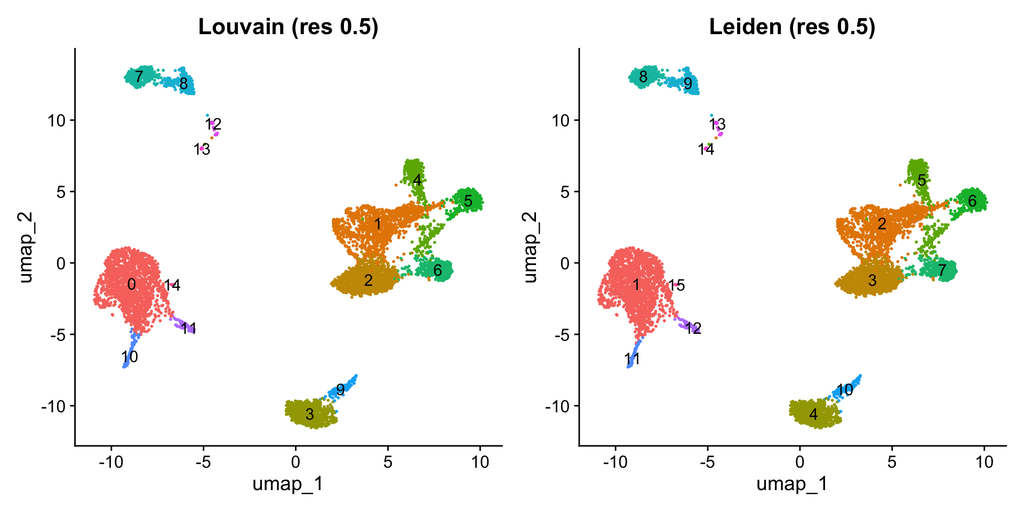

```r
(DimPlot(pbmc, group.by = "louvain", label = TRUE) + ggtitle("Louvain (res 0.5)") + NoLegend()) |
(DimPlot(pbmc, group.by = "leiden",  label = TRUE) + ggtitle("Leiden (res 0.5)")  + NoLegend())
```

¿En qué se diferencian? Tabla de contingencia

```r
tab <- table(Louvain = pbmc$louvain, Leiden = pbmc$leiden)
tab
```

```
#>        Leiden
#> Louvain    1    2    3    4    5    6    7    8    9   10   11   12   13   14
#>      0  1673    0    0    0    0    0    0    0    0    0    0    0    0    0
#>      1     0 1184    0    0    0    0    0    0    0    0    0    0    0    0
#>      2     0    0 1124    0    0    0    0    0    0    0    0    0    0    0
#>      3     0    0    0  742    0    0    0    0    0    0    0    0    0    0
#>      4     0    0    0    0  443    0    0    0    0    0    0    0    0    0
#>      5     0    0    0    0    0  419    0    0    0    0    0    0    0    0
#>      6     0    0    0    0    3    0  403    0    0    0    0    0    0    0
#>      7     0    0    0    0    0    0    0  314    0    0    0    0    0    0
#>      8     0    0    0    0    0    0    0    0  200    0    0    0    0    0
#>      9     0    0    0    0    0    0    0    0    0  142    0    0    0    0
#>      10   21    0    0    0    0    0    0    0    0    0   88    0    0    0
#>      11    0    0    0    0    0    0    0    0    0    0    0   88    0    0
#>      12    0    0    0    0    0    0    0    0    0    0    0    0   35    0
```

[output cut: 19 more lines]

Índice de Rand ajustado: 1 = particiones idénticas, 0 = coincidencia al azar

```r
ari <- function(x, y) {
  tb <- table(x, y)
  n  <- sum(tb)
  ch2 <- function(k) k * (k - 1) / 2
  s_ij <- sum(ch2(tb)); s_i <- sum(ch2(rowSums(tb))); s_j <- sum(ch2(colSums(tb)))
  exp_i <- s_i * s_j / ch2(n)
  (s_ij - exp_i) / ((s_i + s_j) / 2 - exp_i)
}
cat("ARI Louvain vs Leiden:", round(ari(pbmc$louvain, pbmc$leiden), 3), "\n")
```

```
#> ARI Louvain vs Leiden: 0.993
```

La comparación con k-means, que es la figura proyectada en la clase. Para que se vea el problema hay que mirar una partición GRUESA: pedimos pocos grupos y comparamos qué hace cada método con la población más chica.

```r
km_k <- 5
pbmc <- FindClusters(pbmc, resolution = 0.05, algorithm = 4,
                     leiden_method = "igraph",
                     cluster.name = "grafo_grueso", verbose = FALSE)

set.seed(42)
pbmc$kmeans <- factor(kmeans(Embeddings(pbmc, "pca")[, 1:30],
                             centers = km_k, nstart = 10)$cluster)

t_grafo <- sort(table(pbmc$grafo_grueso), decreasing = TRUE)
t_km    <- sort(table(pbmc$kmeans),       decreasing = TRUE)
cat("Grupo más chico  — grafo :", min(t_grafo), "células\n")
```

```
#> Grupo más chico  — grafo : 19 células
```

```r
cat("Grupo más chico  — k-means:", min(t_km),   "células\n")
```

```
#> Grupo más chico  — k-means: 553 células
```

```r
cat("Razón mayor/menor — grafo :", round(max(t_grafo)/min(t_grafo)), "x\n")
```

```
#> Razón mayor/menor — grafo : 189 x
```

```r
cat("Razón mayor/menor — k-means:", round(max(t_km)/min(t_km)),     "x\n")
```

```
#> Razón mayor/menor — k-means: 4 x
```

```r
cat("ARI grafo vs k-means:", round(ari(pbmc$grafo_grueso, pbmc$kmeans), 3), "\n")
```

```
#> ARI grafo vs k-means: 0.647
```

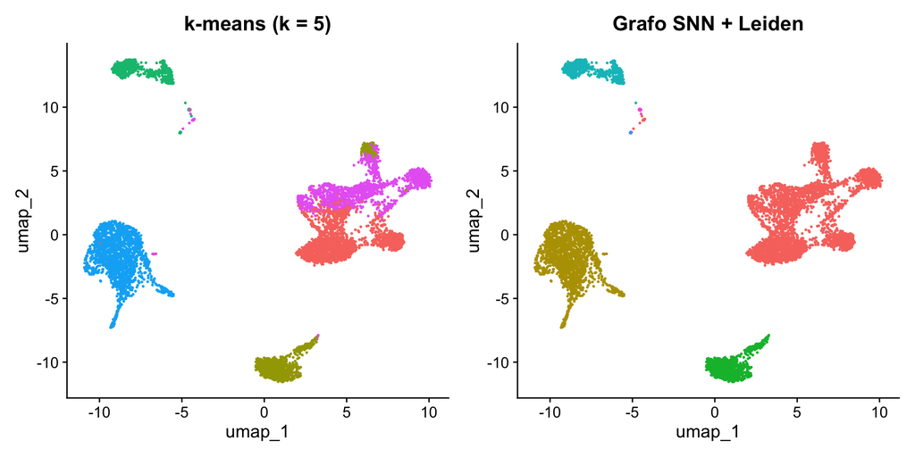

```r
(DimPlot(pbmc, group.by = "kmeans") + ggtitle(paste0("k-means (k = ", km_k, ")")) + NoLegend()) |
(DimPlot(pbmc, group.by = "grafo_grueso") + ggtitle("Grafo SNN + Leiden") + NoLegend())
```

> Mirá el bloque grande: k-means lo parte en tajadas donde no hay ninguna separación, porque busca celdas convexas de tamaño parecido. Y mirá la población más chica: el grafo le da un cluster propio, k-means la absorbe. En un experimento real esa población podría ser justo la que buscás.

> Advertencia honesta: con muchos grupos y poblaciones bien separadas, k-means no lo hace tan mal. El problema aparece donde importa — poblaciones chicas y nubes alargadas.

## 3. La resolución

La resolución controla la granularidad: valores bajos dan pocos clusters grandes, valores altos dan muchos clusters chicos.

**No existe la resolución correcta.** La resolución define la pregunta que estás haciendo. “¿Cuántos tipos celulares hay?” no tiene una respuesta única: depende de si quieres distinguir *linfocito T* de *monocito*, o *T CD4 naive* de *T CD4 de memoria central*.

Lo que sí se puede hacer es elegir con criterio y **reportar la elección**. Dos decisiones deliberadas: - 0.5 está EN el barrido. La resolución que vamos a usar el resto del módulo tiene que ser un nodo del árbol que estamos por mirar; si no, la justificamos con un gráfico que no la contiene. - El barrido corre con Leiden, el mismo algoritmo que recomendamos arriba. Mezclar Louvain en el árbol y Leiden en la resolución de trabajo sería incoherente. Son nueve corridas: tarda alrededor de un minuto.

```r
resoluciones <- c(0.05, 0.1, 0.2, 0.4, 0.5, 0.6, 0.8, 1.2, 2.0)
pbmc <- FindClusters(pbmc, resolution = resoluciones, algorithm = 4,
                     leiden_method = "igraph", verbose = FALSE)

n_clusters <- sapply(paste0("RNA_snn_res.", resoluciones),
                     function(x) nlevels(factor(pbmc[[x]][, 1])))
data.frame(resolucion = resoluciones, n_clusters = as.integer(n_clusters))
```

| resolucion | n_clusters |
| --- | --- |
| 0.05 | 6 |
| 0.10 | 8 |
| 0.20 | 11 |
| 0.40 | 14 |
| 0.50 | 15 |
| 0.60 | 15 |
| 0.80 | 17 |
| 1.20 | 19 |
| 2.00 | 22 |

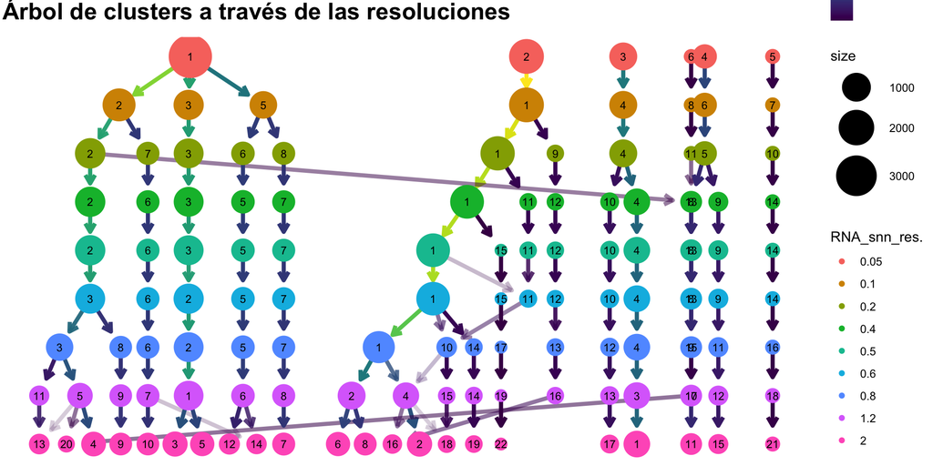

```r
suppressPackageStartupMessages(library(clustree))

clustree(pbmc, prefix = "RNA_snn_res.") +
  labs(title = "Árbol de clusters a través de las resoluciones")
```

### Cómo se lee un clustree

- Cada fila es una resolución; cada nodo, un cluster.
- Las **flechas** muestran de dónde vienen las células cuando aumenta la resolución.
- Un cluster que se divide limpiamente en dos y esos dos se mantienen estables hacia abajo → **subestructura real**.
- Un nodo que recibe flechas de **varios** clusters de la fila anterior (mezcla de colores en las aristas) → el algoritmo está *reorganizando* células, no *refinando* grupos. Eso es señal de sobre-clusterización.

Regla práctica: quédate en la resolución más alta **antes** de que aparezcan cruces masivos.

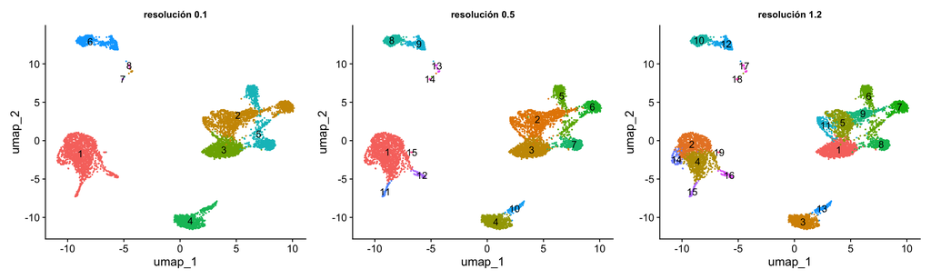

```r
wrap_plots(lapply(c(0.1, 0.5, 1.2), function(r) {
  col <- paste0("RNA_snn_res.", r)
  DimPlot(pbmc, group.by = col, label = TRUE, pt.size = 0.15) +
    ggtitle(paste("resolución", r)) + NoLegend() +
    theme(plot.title = element_text(size = 11))
}), ncol = 3)
```

Fijamos la resolución de trabajo para el resto del módulo

```r
Idents(pbmc) <- "RNA_snn_res.0.5"
pbmc$clusters <- Idents(pbmc)
cat("Resolución de trabajo: 0.5 →", nlevels(pbmc$clusters), "clusters\n")
```

```
#> Resolución de trabajo: 0.5 → 15 clusters
```

```r
table(pbmc$clusters)
```

```
#>
#>    1    2    3    4    5    6    7    8    9   10   11   12   13   14   15
#> 1694 1184 1124  742  446  419  403  314  200  142   88   88   35   23    5
```

## 4. ⚠️ El problema estadístico: doble inmersión (double dipping)

Este es el núcleo de la clase.

## 4.1. Qué hicimos, exactamente

1. Usamos la expresión de ~2.000 genes para construir el grafo.
2. Buscamos la partición que **maximiza la separación** entre grupos.
3. Ahora vamos a testear si esos genes están diferencialmente expresados **entre esos mismos grupos**.

El paso 2 eligió la partición que hace máxima la diferencia. El paso 3 pregunta si la diferencia es significativa. **Es circular.** La hipótesis nula que el test de Wilcoxon evalúa (“estas dos muestras vienen de la misma distribución”) ya fue violada por construcción, no por la biología.

## 4.2. Demostración

Simulemos una matriz de **ruido puro**: conteos de Poisson con una tasa fija por gen, igual para todas las células, sin ninguna estructura de grupos. Por construcción, **no hay ningún gen diferencialmente expresado, porque no hay grupos**. Después clusterizamos y corremos el test.

```r
set.seed(2026)
n_celulas <- 2000     # con 800 el efecto existe pero queda al borde de lo visible
n_genes   <- 1500
```

Conteos de Poisson con una tasa fija por gen (igual para TODAS las células). No hay grupos, no hay genes diferenciales, no hay estructura: solo ruido de muestreo, que es exactamente el ruido que tienen los datos reales.

```r
tasas <- rlnorm(n_genes, meanlog = 0.5, sdlog = 1)
ruido <- matrix(rpois(n_genes * n_celulas, lambda = tasas),
                nrow = n_genes, ncol = n_celulas)
rownames(ruido) <- paste0("gen", seq_len(n_genes))
colnames(ruido) <- paste0("cel", seq_len(n_celulas))
```

Le aplicamos EXACTAMENTE el mismo pipeline que a los datos reales

```r
sim <- CreateSeuratObject(counts = ruido)
sim <- NormalizeData(sim, verbose = FALSE)
sim <- FindVariableFeatures(sim, nfeatures = 1000, verbose = FALSE)
sim <- ScaleData(sim, verbose = FALSE)
sim <- RunPCA(sim, npcs = 20, verbose = FALSE)
sim <- FindNeighbors(sim, dims = 1:20, verbose = FALSE)
sim <- FindClusters(sim, resolution = 0.5, verbose = FALSE)
```

La demostración necesita AL MENOS DOS grupos para poder testear. Sobre ruido puro, cuántos aparecen depende de la versión de Seurat y del azar; si sale uno solo, subimos la resolución hasta que haya dos. Que haga falta subirla no debilita el argumento: lo refuerza. El clustering entrega grupos si se los pedís.

⚠️ El paso importa. Buscamos el corte MÁS GRUESO que el algoritmo produce: dos grupos grandes. Si subimos de a saltos (0.5 → 1 → 2) pasamos de largo esa zona y aterrizamos en seis o siete grupos chicos; el contraste entre los dos mayores queda entonces con pocas células de cada lado y el efecto se diluye. Por eso subimos de a 0.1, desde abajo. Primero, el dato que importa para el argumento: cuántos grupos aparecen a la resolución por defecto, la que uno usaría sin pensarlo.

```r
cat("Clusters a resolución 0.5, sobre datos SIN ninguna estructura:",
    nlevels(sim$seurat_clusters), "\n")
```

```
#> Clusters a resolución 0.5, sobre datos SIN ninguna estructura: 1
```

Para el TEST buscamos otra cosa: el corte más grueso, dos grupos grandes.

```r
res_sim <- 0.1
sim <- FindClusters(sim, resolution = res_sim, verbose = FALSE)
while (nlevels(sim$seurat_clusters) < 2 && res_sim < 2) {
  res_sim <- round(res_sim + 0.1, 2)
  sim <- FindClusters(sim, resolution = res_sim, verbose = FALSE)
}
cat("Resolución más baja que parte el ruido en dos grupos:", res_sim, "\n")
```

```
#> Resolución más baja que parte el ruido en dos grupos: 0.6
```

```r
cat("Grupos que vamos a comparar:", nlevels(sim$seurat_clusters), "\n")
```

```
#> Grupos que vamos a comparar: 2
```

```r
print(table(sim$seurat_clusters))
```

```
#>
#>    0    1
#> 1096  904
```

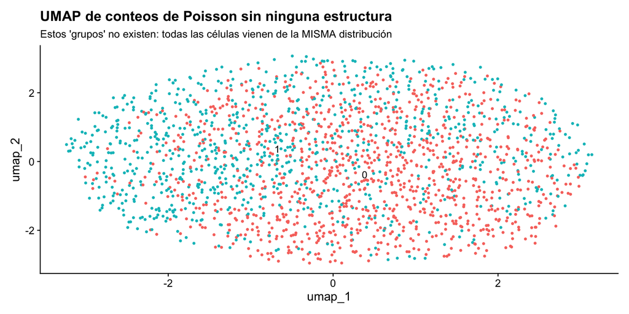

```r
sim <- RunUMAP(sim, dims = 1:20, verbose = FALSE)
DimPlot(sim, label = TRUE) +
  ggtitle("UMAP de conteos de Poisson sin ninguna estructura") +
  labs(subtitle = "Estos 'grupos' no existen: todas las células vienen de la MISMA distribución") +
  NoLegend()
```

> El clustering siempre devuelve clusters. Nunca dice “no hay grupos”.

Ahora la parte que importa: ¿cuántos “marcadores significativos” encuentra el test? OJO con `return.thresh`: su valor por defecto es 0.01 y FindAllMarkers descarta de entrada todo lo que tenga p-valor CRUDO mayor. Si lo dejamos así, estaríamos contando sobre una tabla ya filtrada —y si ningún gen pasa ese filtro, la función devuelve un data.frame vacío SIN COLUMNAS, que rompe cualquier indexado posterior. Lo ponemos en 1 para recibir todo y hacer nosotros el conteo.

```r
marcadores_ruido <- FindAllMarkers(sim, only.pos = TRUE, logfc.threshold = 0,
                                   min.pct = 0, return.thresh = 1, verbose = FALSE)

cat("Genes testeados en total:", nrow(marcadores_ruido), "\n")
```

```
#> Genes testeados en total: 1500
```

```r
if (nrow(marcadores_ruido) == 0) {
  cat("FindAllMarkers no devolvió ninguna fila. Revisa cuántos clusters hay:\n")
  print(table(sim$seurat_clusters))
} else {
  cat("Genes con p_val_adj < 0.05 :", sum(marcadores_ruido$p_val_adj < 0.05), "\n")
  cat("Genes con p_val_adj < 0.01 :", sum(marcadores_ruido$p_val_adj < 0.01), "\n")
  cat("Genes con p_val_adj < 1e-10:", sum(marcadores_ruido$p_val_adj < 1e-10), "\n\n")
  cat("Recordatorio: la respuesta correcta es CERO.\n\n")

  cat("p-valor ajustado más chico encontrado:",
      format(min(marcadores_ruido$p_val_adj), digits = 3), "\n\n")

  print(head(marcadores_ruido[order(marcadores_ruido$p_val_adj),
                              c("cluster", "gene", "avg_log2FC", "p_val_adj")], 10))
}
```

```
#> Genes con p_val_adj < 0.05 : 19
#> Genes con p_val_adj < 0.01 : 11
#> Genes con p_val_adj < 1e-10: 0
#>
#> Recordatorio: la respuesta correcta es CERO.
#>
#> p-valor ajustado más chico encontrado: 6.6e-07
#>
#>         cluster    gene avg_log2FC    p_val_adj
#> gen705        0  gen705  0.2392926 6.603321e-07
#> gen110        0  gen110  0.4678052 1.589607e-05
#> gen265        0  gen265  0.2214890 2.504794e-04
#> gen457        0  gen457  0.1880289 2.755490e-04
#> gen337        0  gen337  0.2829649 7.109747e-04
#> gen19         1   gen19  0.3986410 2.003489e-03
#> gen1125       1 gen1125  0.3106525 2.089749e-03
#> gen525        1  gen525  0.3874283 2.320289e-03
#> gen595        0  gen595  0.4035403 3.527292e-03
#> gen248        1  gen248  0.3788301 3.553037e-03
```

La comparación decisiva

⚠️ Para que esta comparación pruebe algo, los dos paneles tienen que diferir en UNA sola cosa. Si de un lado usáramos `FindAllMarkers` (uno-contra-el-resto, con `only.pos = TRUE`, que además trunca la distribución de p-valores) y del otro un contraste pareado sin filtro de signo, estaríamos cambiando tres cosas a la vez: el origen de los grupos, la estructura del contraste y el filtro. La conclusión no sería atribuible al double dipping.

Por eso los dos paneles usan `FindMarkers`, contraste pareado, sin filtros. Lo único que cambia es DE DÓNDE salieron las dos etiquetas. (a) Dos grupos DERIVADOS de estos mismos datos: los dos clusters más grandes

```r
Idents(sim) <- "seurat_clusters"
dos <- names(sort(table(sim$seurat_clusters), decreasing = TRUE))[1:2]
cat("Comparamos los clusters", dos[1], "y", dos[2], "\n")
```

```
#> Comparamos los clusters 0 y 1
```

```r
pv_clusters <- FindMarkers(sim, ident.1 = dos[1], ident.2 = dos[2],
                           logfc.threshold = 0, min.pct = 0, verbose = FALSE)
```

2. Dos grupos asignados AL AZAR, sin mirar los datos

```r
sim$azar <- factor(sample(c("A", "B"), ncol(sim), replace = TRUE))
Idents(sim) <- "azar"
pv_azar <- FindMarkers(sim, ident.1 = "A", ident.2 = "B",
                       logfc.threshold = 0, min.pct = 0, verbose = FALSE)

cat("Genes con p < 0.05 — clusters:", sum(pv_clusters$p_val < 0.05),
    "| al azar:", sum(pv_azar$p_val < 0.05), "\n")
```

```
#> Genes con p < 0.05 — clusters: 271 | al azar: 82
```

```r
cat("(con ~", nrow(pv_azar), "genes testeados, al azar se esperan ~",
    round(0.05 * nrow(pv_azar)), "por puro azar)\n\n")
```

```
#> (con ~ 1500 genes testeados, al azar se esperan ~ 75 por puro azar)
```

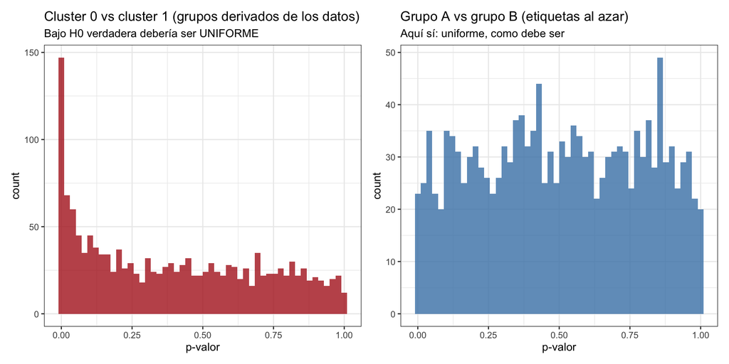

```r
p1 <- ggplot(pv_clusters, aes(p_val)) +
  geom_histogram(bins = 50, fill = "firebrick", alpha = .8) +
  labs(title = paste0("Cluster ", dos[1], " vs cluster ", dos[2], " (grupos derivados de los datos)"),
       subtitle = "Bajo H0 verdadera debería ser UNIFORME", x = "p-valor") + theme_bw()

p2 <- ggplot(pv_azar, aes(p_val)) +
  geom_histogram(bins = 50, fill = "steelblue", alpha = .8) +
  labs(title = "Grupo A vs grupo B (etiquetas al azar)",
       subtitle = "Aquí sí: uniforme, como debe ser", x = "p-valor") + theme_bw()

p1 | p2
```

### 4.3. Qué muestra esta comparación

- **Izquierda:** los dos grupos salieron del clustering de estos mismos datos → los p-valores se apilan contra cero. Falsos positivos masivos.
- **Derecha:** los dos grupos se sortearon sin mirar los datos → distribución uniforme, exactamente lo que predice la teoría bajo la hipótesis nula.

### 4.4. Entonces, ¿qué hacemos?

| Situación | Qué hacer |
| --- | --- |
| Quiero **ordenar** genes candidatos a marcador de un cluster | `FindAllMarkers` está bien. Usa el ranking, **no reportes los p-valores como evidencia inferencial**. |
| Quiero **testear** si un cluster es un grupo real | `ClusterDE` (control sintético) o *count splitting* (`countsplit`): partir los conteos en dos mitades independientes, clusterizar con una y testear con la otra. |
| Quiero comparar **condiciones** (enfermo vs sano) dentro de un tipo celular | **Pseudobulk**. Ver la sección 6. |
| Quiero validar un marcador | Datos independientes: otro dataset, citometría, IHC. |

> **Regla operativa de este curso:** en scRNA-seq, un p-valor de `FindAllMarkers` es una **medida de ranking**, no una probabilidad de error de tipo I. Si en tu tesis escribes “*el gen X está significativamente sobreexpresado en el cluster 3 (p = 2×10⁻³⁰⁰)*”, esa frase no significa lo que parece.

## 5. Marcadores de cluster, usados correctamente

Con la advertencia anterior en mente, buscamos genes característicos de cada cluster. `presto` (instalado en el setup) hace el test de Wilcoxon unas 100 veces más rápido; Seurat lo detecta solo.

Los parámetros que importan más que el p-valor:

- `only.pos = TRUE` — solo genes **enriquecidos** en el cluster (los marcadores útiles son positivos).
- `min.pct` — el gen debe detectarse en al menos ese % de células. Filtra genes que “distinguen” por dropout.
- `logfc.threshold` — magnitud mínima del efecto. **Este es el criterio que de verdad importa.**

```r
Idents(pbmc) <- "clusters"

marcadores <- FindAllMarkers(pbmc, only.pos = TRUE,
                             min.pct = 0.25, logfc.threshold = 0.5,
                             verbose = FALSE)

top5 <- marcadores |>
  group_by(cluster) |>
  slice_max(avg_log2FC, n = 5) |>
  ungroup()

print(as.data.frame(top5[, c("cluster", "gene", "avg_log2FC", "pct.1", "pct.2")]), row.names = FALSE)
```

```
#>  cluster       gene avg_log2FC pct.1 pct.2
#>        1     CYP1B1   9.573375 0.471 0.002
#>        1    S100A12   9.149284 0.956 0.014
#>        1     S100A8   8.897228 0.999 0.065
#>        1     CLEC4E   8.673915 0.505 0.002
#>        1     S100A9   8.532261 1.000 0.096
#>        2    TNFRSF4   4.680210 0.293 0.013
#>        2       AQP3   2.289405 0.560 0.130
#>        2        CD5   2.064114 0.346 0.090
#>        2      GATA3   1.901773 0.272 0.078
#>        2 AC058791.1   1.858674 0.406 0.136
#>        3       FHIT   3.181688 0.251 0.038
#>        3  CHRM3-AS2   3.027456 0.290 0.043
#>        3       CCR7   2.814113 0.558 0.103
#>        3    TRABD2A   2.699624 0.438 0.088
```

[output cut: 61 more lines]

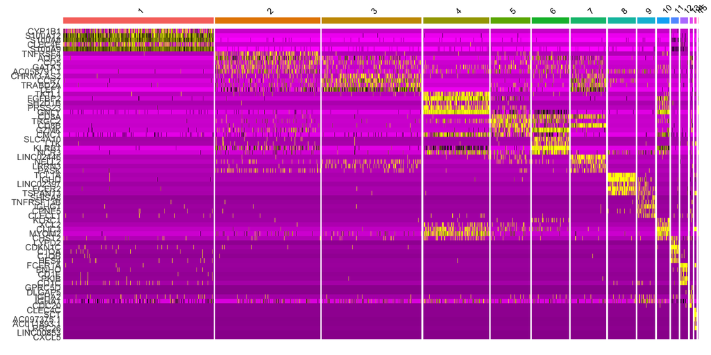

```r
DoHeatmap(pbmc, features = top5$gene, size = 3) + NoLegend()
```

El DotPlot suele ser más informativo que el heatmap: el TAMAÑO del punto = % de células que expresan; el COLOR = nivel medio.

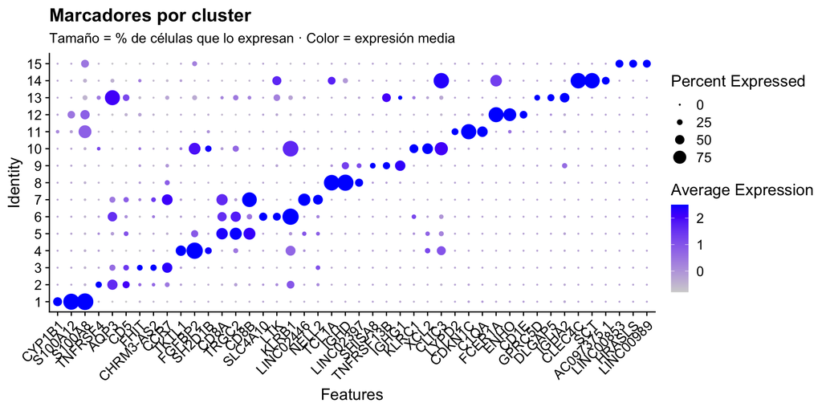

```r
genes_dot <- unique(marcadores |> group_by(cluster) |> slice_max(avg_log2FC, n = 3) |> pull(gene))

DotPlot(pbmc, features = genes_dot) +
  RotatedAxis() +
  labs(title = "Marcadores por cluster",
       subtitle = "Tamaño = % de células que lo expresan · Color = expresión media")
```

Volcano de un contraste puntual entre dos clusters

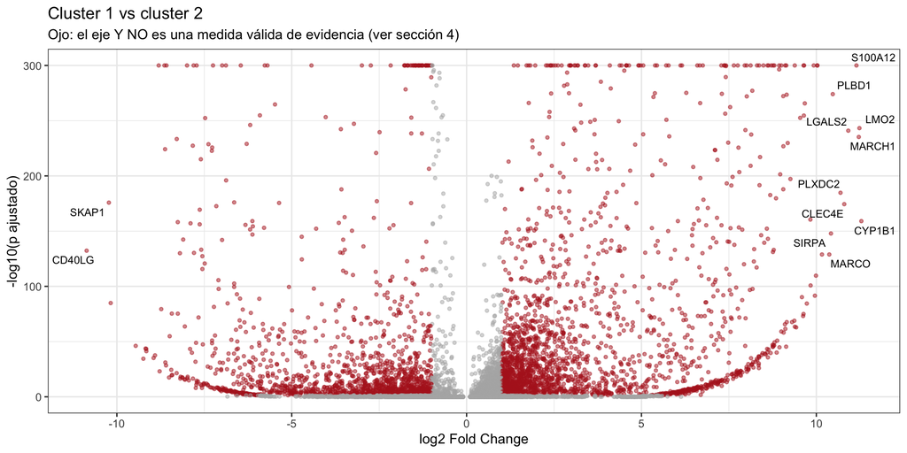

```r
c_a <- levels(pbmc$clusters)[1]; c_b <- levels(pbmc$clusters)[2]
de  <- FindMarkers(pbmc, ident.1 = c_a, ident.2 = c_b, verbose = FALSE)
de$gene <- rownames(de)

ggplot(de, aes(avg_log2FC, -log10(p_val_adj + 1e-300))) +
  geom_point(aes(color = abs(avg_log2FC) > 1 & p_val_adj < 0.05), alpha = .5, size = 1) +
  scale_color_manual(values = c("grey70", "firebrick"), guide = "none") +
  ggrepel::geom_text_repel(
    data = head(de[order(-abs(de$avg_log2FC)), ], 12),
    aes(label = gene), size = 3, max.overlaps = 20) +
  labs(title = paste("Cluster", c_a, "vs cluster", c_b),
       subtitle = "Ojo: el eje Y NO es una medida válida de evidencia (ver sección 4)",
       x = "log2 Fold Change", y = "-log10(p ajustado)") +
  theme_bw()
```

## 6. Comparar condiciones: pseudobulk

Hasta aquí comparamos clusters entre sí. El otro tipo de pregunta —el que aparece en casi todos los proyectos reales— es:

> *“Dentro de los monocitos, ¿qué genes cambian entre pacientes y controles?”*

Aquí hay un segundo problema estadístico, **independiente del double dipping**.

## 6.1. Pseudorreplicación

Si tienes 3 pacientes y 3 controles, y de cada uno recuperas 2.000 monocitos, un test célula a célula ve **6.000 vs 6.000 observaciones**. Pero las 2.000 células de un paciente **no son 2.000 réplicas independientes**: comparten genotipo, tratamiento, hora de extracción, lote de procesamiento. Son *pseudorréplicas*.

El tamaño muestral real es **3 vs 3**.

Al ignorarlo, los p-valores se vuelven astronómicamente pequeños y aparecen cientos de “genes diferenciales” que son variación entre individuos. La documentación oficial de Seurat muestra un ejemplo donde **1.649 genes** son significativos en el análisis single-cell y no lo son en pseudobulk.

## 6.2. La solución

**Sumar los conteos de todas las células del mismo tipo celular dentro de cada muestra** → una muestra, un perfil. Con eso se recupera un diseño de RNA-seq bulk clásico, y se aplican métodos con 15 años de validación: DESeq2, edgeR, limma-voom.

`AggregateExpression()` hace la agregación. Nuestro dataset es de UN donante, así que no tiene réplicas biológicas. Simulamos un diseño para practicar la mecánica: 6 “muestras”, 2 condiciones. ⚠️ Esto es un ejercicio de sintaxis, NO un experimento: las condiciones son arbitrarias, así que NO debería salir nada diferencial. Ese es el punto.

```r
set.seed(7)
pbmc$muestra   <- sample(paste0("S", 1:6), ncol(pbmc), replace = TRUE)
pbmc$condicion <- ifelse(pbmc$muestra %in% c("S1", "S2", "S3"), "control", "tratado")

table(pbmc$muestra, pbmc$condicion)[, ]
```

```
#>
#>      control tratado
#>   S1    1113       0
#>   S2    1192       0
#>   S3    1107       0
#>   S4       0    1147
#>   S5       0    1177
#>   S6       0    1171
```

Usamos identificadores de cluster que empiecen con letra (“C0”, “C1”, …) para que los nombres de columna del pseudobulk sean fáciles de partir.

```r
pbmc$cl_id <- paste0("C", as.character(pbmc$clusters))
```

Agregación: SUMAMOS conteos por (cluster x muestra)

```r
pseudo <- AggregateExpression(pbmc, assays = "RNA",
                              group.by = c("cl_id", "muestra"),
                              return.seurat = FALSE)$RNA

cat("Matriz pseudobulk:", nrow(pseudo), "genes x", ncol(pseudo), "perfiles\n")
```

```
#> Matriz pseudobulk: 18054 genes x 87 perfiles
```

```r
cat("(", nlevels(pbmc$clusters), "clusters x 6 muestras )\n\n")
```

```
#> ( 15 clusters x 6 muestras )
```

```r
cat("Formato de los nombres de columna:\n"); print(head(colnames(pseudo)))
```

```
#> Formato de los nombres de columna:
```

```
#> [1] "C1_S1" "C1_S2" "C1_S3" "C1_S4" "C1_S5" "C1_S6"
```

```r
pseudo[1:4, 1:5]
```

```
#> 4 x 5 sparse Matrix of class "dgCMatrix"
#>            C1_S1 C1_S2 C1_S3 C1_S4 C1_S5
#> AL627309.1     .     .     .     .     1
#> AL669831.5    21    30    12    23    16
#> LINC00115      8     6    10     8    10
#> FAM41C        17    17    14    15    12
```

Separamos cluster y muestra a partir de los nombres de columna

```r
partes <- do.call(rbind, strsplit(colnames(pseudo), "_", fixed = TRUE))
info <- data.frame(col = colnames(pseudo),
                   cluster = partes[, 1],
                   muestra = partes[, 2])
head(info)
```

|  | col | cluster | muestra |
| --- | --- | --- | --- |
| 1 | C1_S1 | C1 | S1 |
| 2 | C1_S2 | C1 | S2 |
| 3 | C1_S3 | C1 | S3 |
| 4 | C1_S4 | C1 | S4 |
| 5 | C1_S5 | C1 | S5 |
| 6 | C1_S6 | C1 | S6 |

Tomamos un cluster y corremos DESeq2 a nivel de MUESTRA

```r
cl   <- info$cluster[1]
sub  <- info[info$cluster == cl, ]
mat  <- round(as.matrix(pseudo[, sub$col]))
mat  <- mat[rowSums(mat) > 10, ]

coldata <- data.frame(
  row.names = sub$col,
  condicion = factor(ifelse(sub$muestra %in% c("S1", "S2", "S3"), "control", "tratado"),
                     levels = c("control", "tratado"))
)
print(coldata)
```

```
#>       condicion
#> C1_S1   control
#> C1_S2   control
#> C1_S3   control
#> C1_S4   tratado
#> C1_S5   tratado
#> C1_S6   tratado
```

```r
if (!requireNamespace("DESeq2", quietly = TRUE))
  BiocManager::install("DESeq2", ask = FALSE, update = FALSE)
suppressPackageStartupMessages(library(DESeq2))

dds <- DESeqDataSetFromMatrix(mat, coldata, ~ condicion)
dds <- DESeq(dds, quiet = TRUE)
res <- results(dds)

cat("Cluster", cl, "— pseudobulk (n = 3 vs 3):\n")
```

```
#> Cluster C1 — pseudobulk (n = 3 vs 3):
```

```r
cat("  Genes con padj < 0.05:", sum(res$padj < 0.05, na.rm = TRUE), "\n")
```

```
#>   Genes con padj < 0.05: 0
```

El mismo contraste, pero célula a célula (lo que NO hay que hacer)

```r
cl_orig <- sub("^C", "", cl)          # volvemos al identificador original
Idents(pbmc) <- "clusters"

sc_res <- FindMarkers(pbmc, subset.ident = cl_orig, group.by = "condicion",
                      ident.1 = "tratado", ident.2 = "control",
                      logfc.threshold = 0, verbose = FALSE)

cat("MISMO contraste, test célula a célula:\n")
```

```
#> MISMO contraste, test célula a célula:
```

```r
cat("  Genes con p_val_adj < 0.05:", sum(sc_res$p_val_adj < 0.05), "\n\n")
```

```
#>   Genes con p_val_adj < 0.05: 0
```

```r
cat("Las condiciones fueron asignadas AL AZAR: la respuesta correcta es 0.\n")
```

```
#> Las condiciones fueron asignadas AL AZAR: la respuesta correcta es 0.
```

```r
cat("Cada gen que aparezca aquí es un falso positivo.\n")
```

```
#> Cada gen que aparezca aquí es un falso positivo.
```

> **La comparación de estos dos bloques es el resumen de la clase.** Mismo dato, misma pregunta, mismo software. La diferencia está solo en qué se considera una unidad experimental independiente.

> En un experimento real con efecto verdadero, el pseudobulk seguiría encontrando los genes que realmente cambian — pero sin arrastrar cientos de falsos positivos. No es un método más conservador porque sí: es el método que responde la pregunta que uno cree estar haciendo.

## 6.3. Por qué esto importa: una simulación

El bloque anterior enseña la **mecánica** de `AggregateExpression` + DESeq2, pero no puede demostrar el problema: nuestro dataset es de un solo donante, así que al sortear las “muestras” no hay ninguna variabilidad entre ellas. Sin variabilidad entre individuos, el test célula a célula tampoco falla — y entonces la comparación no prueba nada.

Simulemos el caso real: **6 donantes**, 3 control y 3 tratado, 400 células cada uno, y **ningún efecto de condición**. Lo único que varía es de donante a donante, como en cualquier experimento con personas. La respuesta correcta sigue siendo cero.

```r
set.seed(11)
n_g <- 1500; n_m <- 6; n_c <- 400
cond_m <- rep(c("control", "tratado"), each = 3)     # la condición es de la MUESTRA

simular <- function(sigma) {
  tasa_base <- rlnorm(n_g, meanlog = 0.5, sdlog = 1)
  # variabilidad biológica entre donantes; ningún término de condición
  tasa <- tasa_base * exp(matrix(rnorm(n_g * n_m, 0, sigma), n_g, n_m))
  M <- matrix(rpois(n_g * n_m * n_c, lambda = tasa[, rep(seq_len(n_m), each = n_c)]),
              nrow = n_g)
  list(M = M, muestra = rep(seq_len(n_m), each = n_c))
}
```

Wilcoxon vectorizado (aproximación normal con corrección por empates): mismo test que usa Seurat por defecto, pero para las 1.500 filas de una sola vez.

```r
wilcox_filas <- function(M, g) {
  n1 <- sum(g); n2 <- sum(!g); n <- n1 + n2
  R <- t(apply(M, 1, rank))
  W <- rowSums(R[, g, drop = FALSE])
  emp <- apply(M, 1, function(x) { tt <- table(x); sum(tt^3 - tt) })
  sdW <- sqrt(n1 * n2 / 12 * ((n + 1) - emp / (n * (n - 1))))
  2 * pnorm(-abs((W - n1 * (n + 1) / 2) / sdW))
}

falsos <- function(sigma) {
  sim <- simular(sigma)
  M <- sim$M; muestra <- sim$muestra
  cond_cel <- cond_m[muestra]

  # (a) cada célula como una réplica
  tot <- colSums(M)
  Mn  <- log1p(t(t(M) / pmax(tot, 1) * 1e4))
  p_cel <- wilcox_filas(Mn, cond_cel == "control")

  # (b) pseudobulk: sumar los conteos de cada muestra -> 6 perfiles -> 3 vs 3
  pb    <- sapply(seq_len(n_m), function(k) rowSums(M[, muestra == k, drop = FALSE]))
  lcpm  <- log2(t(t(pb) / colSums(pb)) * 1e6 + 1)
  p_pb  <- apply(lcpm, 1, function(x)
                 t.test(x[cond_m == "control"], x[cond_m == "tratado"])$p.value)

  c(celula     = sum(p.adjust(p_cel, "BH") < 0.05),
    pseudobulk = sum(p.adjust(p_pb,  "BH") < 0.05))
}

cat("Falsos positivos (p ajustado < 0.05) — la respuesta correcta es 0:\n\n")
```

```
#> Falsos positivos (p ajustado < 0.05) — la respuesta correcta es 0:
```

```r
tabla <- t(sapply(c(0, 0.1, 0.3), falsos))
rownames(tabla) <- paste("sigma =", c(0, 0.1, 0.3))
print(tabla)
```

```
#>             celula pseudobulk
#> sigma = 0        0          0
#> sigma = 0.1    606          0
#> sigma = 0.3   1153          0
```

> Leé la tabla de arriba hacia abajo.

> Con `sigma = 0` —donantes idénticos— el test célula a célula **no falla**. O sea: el problema no es tener muchas células.

> En cuanto los donantes empiezan a diferir entre sí, que es lo que pasa siempre, el test célula a célula declara diferencial a buena parte del transcriptoma. El pseudobulk no encuentra nada, en las tres filas, que es lo correcto.

> **El mecanismo:** las células de un mismo donante no son independientes. Al ignorarlo, la variabilidad ENTRE INDIVIDUOS entra en la cuenta como si fuera variabilidad ENTRE CÉLULAS, y el test la lee como señal.

> Ojo con la confusión frecuente: la pseudorreplicación y el *double dipping* de la sección 4 son problemas **independientes**. Uno es usar los datos dos veces; el otro es contar mal las unidades experimentales. Se pueden tener los dos a la vez.

### Requisitos para pseudobulk

- **Al menos 3 réplicas biológicas por condición** (individuos distintos, no pocillos distintos).
- Suficientes células por muestra y tipo celular (~20 como mínimo grosero; con menos, el perfil agregado es inestable).
- Cuidado con la composición: si una condición tiene muchas más células de un tipo, eso es en sí mismo un resultado (abundancia diferencial, que se analiza aparte con métodos como `miloR` o `scCODA`).

```r
saveRDS(pbmc, ck2)
tam_archivo(ck2)
```

```
#> results/clase2_pbmc_clusterizado.rds - 262.9 MB
```

## 7. Síntesis

1. El clustering por grafos (KNN → SNN → modularidad) no supone forma ni tamaño de los clusters. **Leiden** es preferible a Louvain y desde Seurat 5.3.1 corre en R puro.
2. **La resolución define la pregunta.** Se elige con `clustree` y criterios de estabilidad, y se **reporta**.
3. **El clustering siempre devuelve clusters**, incluso sobre ruido puro.
4. **Los p-valores post-clustering no son p-valores.** Sirven para rankear candidatos. Para inferencia hay `ClusterDE` y *count splitting*.
5. **Para comparar condiciones: pseudobulk.** Las células de una muestra no son réplicas independientes.